# HW1

Intermediate Statistics

Read Gelman, Hill and Vehtari Chapters 1 through 4. Then, respond to the following questions.

## Part 1

1. Explain what the term *inference* means in your own words. Describe how statistical analysis generally relates to inference and scientific knowledge. Distinguish key differences between classical approaches to inference and Bayesian approaches to inference. (1-3 paragraphs)

```r
2+2
```

```
## [1] 4
```

2. Briefly describe your past experience with statistics, math, and programming. What areas do you feel strong in? In what areas do you think you’ll need extra support? (PS everyone can do this and it’s ok to feel overwhelmed!)

## Part 2

For the following, complete the listed problems from the Exercises at the end of each chapter.

3.1 *Weighted averages*

3.3 *Probability distributions*

Hint: the code chunk below shows how to plot a Normal distribution with mu=0, sigma = 1 using ggplot. You may need to adjust plot_data as you modify mu and sigma.

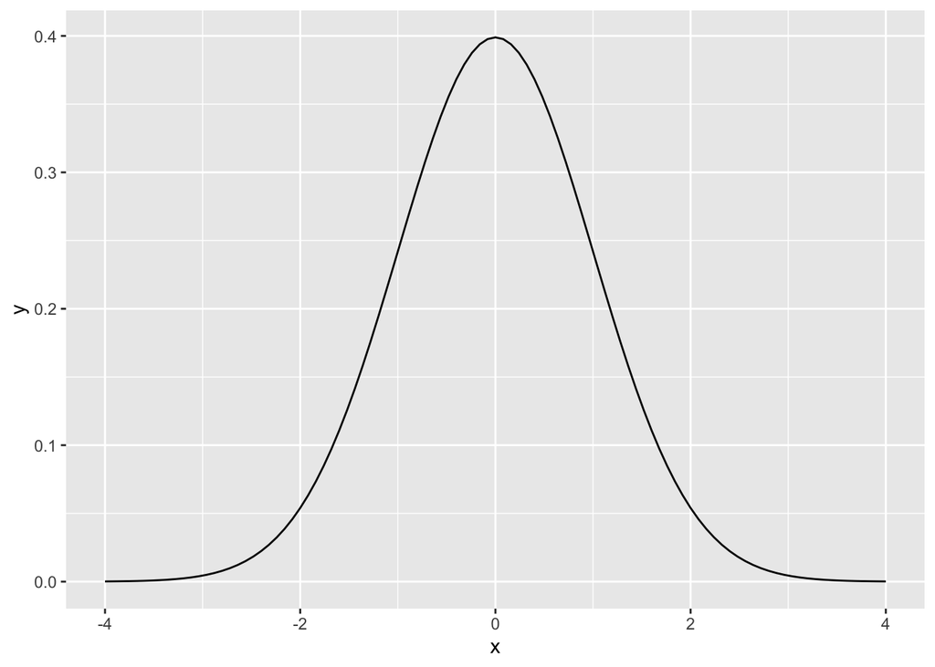

```r
# load packages
library(tidyverse)
# establish bounds for x
plot_data<-data.frame(x = c(-4, 4))
# plot
ggplot(plot_data,
       aes(x = x)) +
  # stat_function evaluates the specified function over x (Normal PDF here)
  # args lets us modify the call to dnorm with arguments
  stat_function(fun = dnorm,
                args = list(mean = 0, sd = 1))
```

3.6 *Linear transformations*

Hint: the code chunk below generates a line plot with specified intercept and slope using ggplot

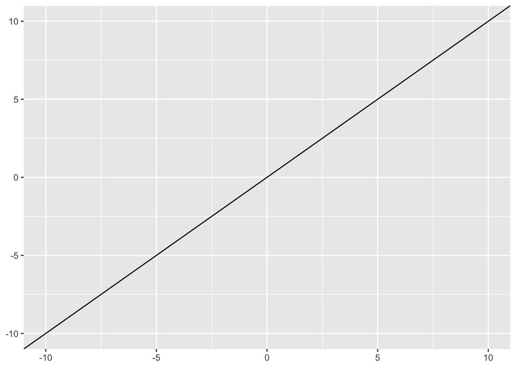

```r
ggplot() +
  geom_abline(slope = 1, intercept = 0) +
  # lims() specifies limits of plotting window
  lims(x = c(-10, 10), y = c(-10, 10))
```

3.8 *Correlated random variables*

4.1 *Comparison of proportions*

4.2 *Choosing sample size*

4.3 *Comparison of proportions*

## Part 3

There are two options for the course final project.

1. Conduct a collaborative research project using data on police violence that the instructor will scaffold and advise. This project will be supported in lab sessions.
2. Conduct an independent research project on a topic of your own choosing.

Tell me which option you are pursuing, then do the following:

*If pursuing option 1*, access and explore the data available in the course repository at `~/data/mpv_1_3_24.csv`. Read some prior research I’ve conducted using similar data available [here](https://www.pnas.org/doi/abs/10.1073/pnas.1821204116). Using group_by() and summarize() compute year-specific counts of people killed by police. Provide a line plot using ggplot() and geom_line() that visualizes the total number of people killed by police annually for 2012 - 2024. Briefly discuss your findings, and interpret in dialogue with prior research.

*If pursuing option 2*, complete the following exercises from the book: 1.10, 2.10, and 4.10. Provide appropriate context and discussion.